# Normal multivariante, distancia de Mahalanobis y gráfico Q-Q en clientes de tarjeta de crédito

Quién es raro de verdad cuando se miran las variables al tiempo

Estadística Multidimensional, Universidad Distrital Francisco José de Caldas

Miércoles 28 de octubre de 2026

# 1 Introducción

> **¿Hay clientes que son raros en la combinación de sus variables financieras, aunque ninguna cifra por separado sea extrema?**

un cliente con una factura alta en septiembre y una factura casi en cero en agosto. Ni una cifra ni la otra son raras si se miran por separado. Pero las facturas de meses consecutivos tienden a parecerse, así que esa combinación puede ser rara aunque cada valor, solo, pase cualquier revisión.

# 2 Los datos

Se usa `skip = 1` porque la primera fila del archivo trae etiquetas (X1, X2, …) y los nombres reales están en la segunda.

```r
ruta <- file.path("..", "DATASET", "credit.xls")
stopifnot(file.exists(ruta))

credit <- as.data.frame(read_excel(ruta, skip = 1))
dim(credit)
```

```
## [1] 30000    25
```

La distancia de Mahalanobis necesita variables continuas, así que se usan 14: `LIMIT_BAL`, `AGE`, las seis facturas (`BILL_AMT`) y los seis pagos (`PAY_AMT`).

```r
facturas  <- paste0("BILL_AMT", 1:6)
pagos     <- paste0("PAY_AMT", 1:6)
continuas <- c("LIMIT_BAL", "AGE", facturas, pagos)

M <- as.matrix(credit[continuas])
p <- length(continuas)
c(clientes = nrow(M), variables_continuas = p)
```

```
##            clientes variables_continuas
##               30000                  14
```

```r
resumen <- data.frame(
  variable   = continuas,
  minimo     = sapply(credit[continuas], min),
  q1         = sapply(credit[continuas], function(v) quantile(v, 0.25, names = FALSE)),
  mediana    = sapply(credit[continuas], median),
  media      = sapply(credit[continuas], mean),
  q3         = sapply(credit[continuas], function(v) quantile(v, 0.75, names = FALSE)),
  maximo     = sapply(credit[continuas], max),
  desviacion = sapply(credit[continuas], sd),
  row.names  = NULL)
resumen[-1] <- round(resumen[-1], 1)
resumen
```

| variable | minimo | q1 | mediana | media | q3 | maximo | desviacion |
| --- | --- | --- | --- | --- | --- | --- | --- |
| LIMIT_BAL | 10000 | 50000.0 | 140000.0 | 167484.3 | 240000.0 | 1000000 | 129747.7 |
| AGE | 21 | 28.0 | 34.0 | 35.5 | 41.0 | 79 | 9.2 |
| BILL_AMT1 | -165580 | 3558.8 | 22381.5 | 51223.3 | 67091.0 | 964511 | 73635.9 |
| BILL_AMT2 | -69777 | 2984.8 | 21200.0 | 49179.1 | 64006.2 | 983931 | 71173.8 |
| BILL_AMT3 | -157264 | 2666.2 | 20088.5 | 47013.2 | 60164.8 | 1664089 | 69349.4 |
| BILL_AMT4 | -170000 | 2326.8 | 19052.0 | 43262.9 | 54506.0 | 891586 | 64332.9 |
| BILL_AMT5 | -81334 | 1763.0 | 18104.5 | 40311.4 | 50190.5 | 927171 | 60797.2 |
| BILL_AMT6 | -339603 | 1256.0 | 17071.0 | 38871.8 | 49198.2 | 961664 | 59554.1 |
| PAY_AMT1 | 0 | 1000.0 | 2100.0 | 5663.6 | 5006.0 | 873552 | 16563.3 |
| PAY_AMT2 | 0 | 833.0 | 2009.0 | 5921.2 | 5000.0 | 1684259 | 23040.9 |

[output cut: 4 more lines]

Las variables están en escalas muy distintas: la desviación de `AGE` es 9,2 años, la de `LIMIT_BAL` es 129 748 y las de las facturas van de 59 554 a 73 636. En casi todos los montos la media supera a la mediana (en `LIMIT_BAL` 167 484 contra 140 000; en `BILL_AMT1` 51 223 contra 22 382; en `PAY_AMT1` 5 664 contra 2 100). Las facturas tienen mínimos negativos, entre -69 777 y -339 603, y los pagos tienen mínimo 0. Los máximos están muy lejos del tercer cuartil: `PAY_AMT2` llega a 1 684 259 con un tercer cuartil de 5 000, y `BILL_AMT3` llega a 1 664 089 con un tercer cuartil de 60 165.

Eso anticipa que la comparación entre las distancias euclidiana y de Mahalanobis va a ser muy distinta, porque las escalas difieren por varios órdenes de magnitud. Los mínimos negativos de las facturas son saldos a favor y hay que tenerlos presentes si se transforma con logaritmo.

se trabaja con las 14 variables continuas, primero en su escala original y luego, si el Q-Q lo exige, en una escala transformada.

# 3 La distancia de Mahalanobis

la distancia de Mahalanobis mide qué tan lejos está un cliente del centro, teniendo en cuenta que las variables van juntas. La compañía de las facturas se ve directamente en su correlación:

```r
round(cor(M[, facturas]), 2)
```

```
##           BILL_AMT1 BILL_AMT2 BILL_AMT3 BILL_AMT4 BILL_AMT5 BILL_AMT6
## BILL_AMT1      1.00      0.95      0.89      0.86      0.83      0.80
## BILL_AMT2      0.95      1.00      0.93      0.89      0.86      0.83
## BILL_AMT3      0.89      0.93      1.00      0.92      0.88      0.85
## BILL_AMT4      0.86      0.89      0.92      1.00      0.94      0.90
## BILL_AMT5      0.83      0.86      0.88      0.94      1.00      0.95
## BILL_AMT6      0.80      0.83      0.85      0.90      0.95      1.00
```

## 3.1 Las dos distancias sobre los mismos clientes

Se calculan sobre los 30 000 clientes y en la escala original de las variables. Se define una función auxiliar para no repetir el cálculo más adelante.

```r
mahal2 <- function(X) mahalanobis(X, colMeans(X), cov(X))

d2_crudo     <- mahal2(M)
euclid_crudo <- sqrt(rowSums((M - matrix(colMeans(M), nrow(M), p, byrow = TRUE))^2))

k <- sum(d2_crudo > qchisq(0.99, df = p))   # cuántos pasan el corte del 99 %
c(correlacion_entre_las_dos = round(cor(euclid_crudo, sqrt(d2_crudo)), 3),
  k_mas_lejanos = k,
  coinciden_en_ese_top = length(intersect(order(euclid_crudo, decreasing = TRUE)[1:k],
                                          order(d2_crudo,     decreasing = TRUE)[1:k])))
```

```
## correlacion_entre_las_dos             k_mas_lejanos      coinciden_en_ese_top
##                     0.639                  2318.000                  1002.000
```

```r
rango_eu <- rank(-euclid_crudo, ties.method = "first")
rango_ma <- rank(-d2_crudo,     ties.method = "first")

elegidos <- c(which.max(euclid_crudo),            # el más lejano en euclidiana
              which.max(d2_crudo),                # el más lejano en Mahalanobis
              which.max(rango_eu - rango_ma),     # lejos en Mahalanobis, cerca en euclidiana
              which.min(rango_eu - rango_ma))     # lejos en euclidiana, cerca en Mahalanobis

data.frame(
  caso = c("Más lejano en euclidiana", "Más lejano en Mahalanobis",
           "Cerca en euclidiana, lejos en Mahalanobis",
           "Lejos en euclidiana, cerca en Mahalanobis"),
  credit[elegidos, c("ID", continuas)],
  euclidiana = round(euclid_crudo[elegidos], 1),
  mahalanobis = round(d2_crudo[elegidos], 1),
  rango_euclidiana = rango_eu[elegidos],
  rango_mahalanobis = rango_ma[elegidos],
  row.names = NULL)
```

| caso | ID | LIMIT_BAL | AGE | BILL_AMT1 | BILL_AMT2 | BILL_AMT3 | BILL_AMT4 | BILL_AMT5 | BILL_AMT6 | PAY_AMT1 | PAY_AMT2 | PAY_AMT3 | PAY_AMT4 | PAY_AMT5 | PAY_AMT6 | euclidiana | mahalanobis | rango_euclidiana | rango_mahalanobis |
| --- | --- | --- | --- | --- | --- | --- | --- | --- | --- | --- | --- | --- | --- | --- | --- | --- | --- | --- | --- |
| Más lejano en euclidiana | 5297 | 500000 | 33 | 125 | -18088 | 1664089 | 121757 | 97115 | 377217 | 4366 | 1684259 | 121831 | 97670 | 379267 | 26759 | 2415828.8 | 8119.0 | 1 | 1 |
| Más lejano en Mahalanobis | 5297 | 500000 | 33 | 125 | -18088 | 1664089 | 121757 | 97115 | 377217 | 4366 | 1684259 | 121831 | 97670 | 379267 | 26759 | 2415828.8 | 8119.0 | 1 | 1 |
| Cerca en euclidiana, lejos en Mahalanobis | 6948 | 150000 | 64 | 56852 | 58031 | 59202 | 60304 | 61650 | 0 | 2688 | 2730 | 2680 | 2850 | 0 | 0 | 53858.3 | 23.8 | 29454 | 2744 |
| Lejos en euclidiana, cerca en Mahalanobis | 23142 | 20000 | 34 | 0 | 0 | 0 | 0 | 0 | 0 | 0 | 0 | 0 | 0 | 0 | 0 | 184878.2 | 1.5 | 7053 | 25043 |

el cliente 5297 es el más lejano en las dos distancias (euclidiana 2 415 828,8; Mahalanobis 8 119,0), con una factura de julio (`BILL_AMT3`) de 1 664 089 y un pago de agosto (`PAY_AMT2`) de 1 684 259. El 6948 es de los más cercanos al centro en euclidiana (puesto 29 454 de 30 000) y tiene Mahalanobis de 23,8. El 23142, con todo en cero, tiene euclidiana de 184 878,2 (puesto 7 053) y Mahalanobis de 1,5. la euclidiana la dominan las variables de mayor escala: en el cliente 5297, `BILL_AMT3` y `PAY_AMT2` explican cerca del 93 % del cuadrado de su distancia. Sus valores son coherentes entre sí (de mayo a agosto, cada pago es casi igual a la factura del mes anterior), lo único llamativo es que la factura de julio es 3,3 veces su límite. El 6948 pasa apenas el corte del 95 % (23,7) y queda lejos del 99 % (29,1): no es raro, rompe la regla de que las facturas consecutivas se parecen (abril en 0 y mayo en 61 650). El 23142 está lejos en euclidiana porque todas sus variables están por debajo del promedio, pero casi en el centro según Mahalanobis, porque todos los montos bajan juntos, que es la dirección en la que más varía la base.

la euclidiana confunde el nivel de los montos con rareza. Para buscar casos que revisar se usa Mahalanobis.

## 3.2 Los cortes de la chi-cuadrado

Si las 14 variables fueran una campana multivariante perfecta, las distancias al cuadrado se repartirían como una chi-cuadrado con 14 grados de libertad, y eso da los cortes para decidir qué es lejos. Se definen tres funciones auxiliares que se reutilizan con la escala transformada.

```r
tabla_cortes <- function(d2, p) {
  cortes <- qchisq(c(0.95, 0.99, 0.999), df = p)
  data.frame(
    corte = c("95 %", "99 %", "99,9 %"),
    valor_de_la_distancia = round(cortes, 2),
    esperados_por_encima = c("5 %", "1 %", "0,1 %"),
    observados = sapply(cortes, function(q) sum(d2 > q)),
    observados_pct = paste0(round(100 * sapply(cortes, function(q) mean(d2 > q)), 2), " %"))
}

qq_d2 <- function(d2, p, titulo, log = FALSE) {
  n  <- length(d2)
  qq <- data.frame(teorica = qchisq(ppoints(n), df = p), observada = sort(d2))
  g <- ggplot(qq, aes(x = teorica, y = observada)) +
    geom_point(alpha = 0.3, size = 0.8, color = "steelblue") +
    geom_abline(slope = 1, intercept = 0, color = "firebrick", linewidth = 1) +
    geom_vline(xintercept = qchisq(0.99, df = p), linetype = "dashed") +
    labs(title = titulo,
         subtitle = paste0(
                           if (log) " (ejes en escala logarítmica)" else ""),
         x = "Distancia que debería tener", y = "Distancia que tiene")
  if (log) g <- g + scale_x_log10() + scale_y_log10()
  g
}

tabla_qq <- function(d2, p) {
  pr <- c(0.50, 0.75, 0.90, 0.95, 0.99, 0.999)
  data.frame(percentil = c("50 %", "75 %", "90 %", "95 %", "99 %", "99,9 %"),
             observada = round(quantile(d2, pr, names = FALSE), 2),
             teorica   = round(qchisq(pr, df = p), 2))
}
```

```r
round(summary(d2_crudo), 2)
```

```
##    Min. 1st Qu.  Median    Mean 3rd Qu.    Max.
##    0.20    1.82    3.20   14.00    7.35 8118.96
```

```r
tabla_cortes(d2_crudo, p)
```

| corte | valor_de_la_distancia | esperados_por_encima | observados | observados_pct |
| --- | --- | --- | --- | --- |
| 95 % | 23.68 | 5 % | 2751 | 9.17 % |
| 99 % | 29.14 | 1 % | 2318 | 7.73 % |
| 99,9 % | 36.12 | 0,1 % | 1920 | 6.4 % |

Hay muchísimos más clientes por encima de los cortes de lo esperado buena parte de esa cola puede ser **efecto de la asimetría** (distribuciones con cola larga a la derecha) y no de observaciones genuinamente anómalas La distancia de Mahalanobis sobre datos crudos supone normalidad multivariante, supuesto que estas variables no cumplen.

# 4 El gráfico Q-Q

El gráfico Q-Q pone en el eje horizontal la distancia que **debería** tener cada cliente si los datos fueran normales multivariantes, y en el vertical la que **tiene**. Si los datos se portan, los puntos caen sobre la recta.

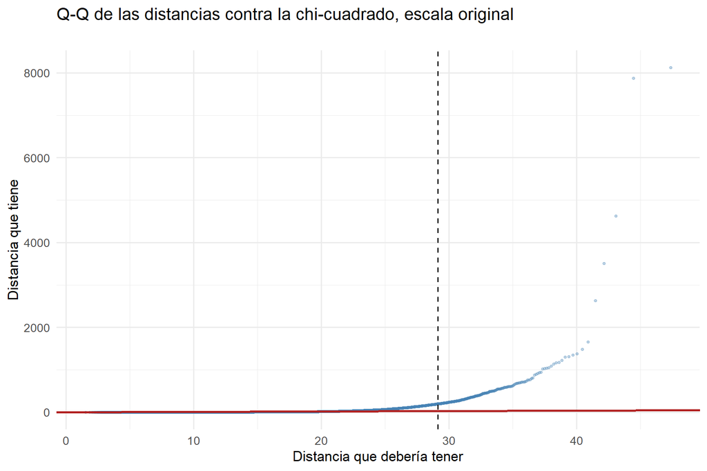

```r
qq_d2(d2_crudo, p, "Q-Q de las distancias contra la chi-cuadrado, escala original")
```

Como las colas de esta base son muy largas, el máximo aplasta al resto de la nube. Se repite el gráfico con los ejes en escala logarítmica, donde la recta sigue siendo la diagonal:

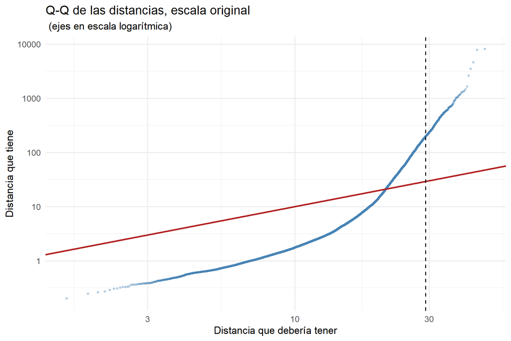

```r
qq_d2(d2_crudo, p, "Q-Q de las distancias, escala original", log = TRUE)
```

```r
tabla_qq(d2_crudo, p)
```

| percentil | observada | teorica |
| --- | --- | --- |
| 50 % | 3.20 | 13.34 |
| 75 % | 7.35 | 17.12 |
| 90 % | 21.21 | 21.06 |
| 95 % | 46.78 | 23.68 |
| 99 % | 198.27 | 29.14 |
| 99,9 % | 730.71 | 36.12 |

Ubicando el caso en la tabla de referencia: el gráfico no sigue la recta en el centro y solo se despega al final, sino que está curvado desde el principio (observado por debajo de lo teórico en 50 % y 75 %, muy por encima en la cola). Esa doble desviación es la firma de variables torcidas (asimetría multivariante), no de una simple cola de casos raros. Con 14 variables donde varias son montos muy sesgados a la derecha, la distancia de Mahalanobis crudo viola el supuesto de normalidad multivariante, y por eso ni siquiera el cuerpo central de los datos cae sobre teórica.

| Qué se ve en el Q-Q | Qué significa | Qué se hace |
| --- | --- | --- |
| Se despega **solo en la cola** | Hay casos raros, el cuerpo está bien | Identificarlos y decidir sobre ellos; seguir |
| Se curva **desde el principio** | Alguna variable está torcida | Transformarla (logaritmo, raíz) y volver a mirar |
| Dos tramos con pendientes distintas | Hay **dos grupos** mezclados | Separarlos y analizar cada uno; no promediar |
| Se despega **hacia abajo** | Menos dispersión de la esperada | Sospechar de un tope o un piso en la escala |

## 4.1 La prueba formal

La prueba de Mardia contrasta la asimetría y la curtosis multivariantes. Como exige una matriz de tamaño n por n (con 30 000 clientes pesaría unos 7 GB), se aplica sobre una **muestra de 2 000 clientes**.

```r
mardia <- function(X) {
  X  <- as.matrix(X)
  n  <- nrow(X); k <- ncol(X)
  Xc <- sweep(X, 2, colMeans(X))
  S  <- crossprod(Xc) / n
  D  <- Xc %*% solve(S) %*% t(Xc)
  b1 <- sum(D^3) / n^2
  b2 <- mean(diag(D)^2)
  gl <- k * (k + 1) * (k + 2) / 6
  est_asim <- n * b1 / 6
  z_curt   <- (b2 - k * (k + 2)) / sqrt(8 * k * (k + 2) / n)
  data.frame(prueba = c("Asimetría", "Curtosis"),
             estadistico = round(c(est_asim, z_curt), 2),
             p_valor = format.pval(c(pchisq(est_asim, gl, lower.tail = FALSE),
                                     2 * pnorm(-abs(z_curt))), eps = 0.001))
}

set.seed(1)
idx_mardia <- sample(nrow(M), 2000)
mardia(M[idx_mardia, ])
```

| prueba | estadistico | p_valor |
| --- | --- | --- |
| Asimetría | 787601.02 | < 0.001 |
| Curtosis | 3949.83 | < 0.001 |

```r
asimetria <- function(X) round(apply(X, 2, function(x) mean((x - mean(x))^3) / sd(x)^3), 2)
data.frame(variable = continuas, asimetria = asimetria(M), row.names = NULL)
```

| variable | asimetria |
| --- | --- |
| LIMIT_BAL | 0.99 |
| AGE | 0.73 |
| BILL_AMT1 | 2.66 |
| BILL_AMT2 | 2.70 |
| BILL_AMT3 | 3.09 |
| BILL_AMT4 | 2.82 |
| BILL_AMT5 | 2.88 |
| BILL_AMT6 | 2.85 |
| PAY_AMT1 | 14.67 |
| PAY_AMT2 | 30.45 |

[output cut: 4 more lines]

con muchos datos cualquier desviación mínima hace que Mardia rechace, así que el p-valor por sí solo dice poco. Vale más el Q-Q del paso anterior, que muestra *cuánto* y *dónde* se desvían los datos y ese Q-Q se explica directamente con esta tabla: las asimetrías extremas de los PAY_AMT (10–30) son las que generan la **cola larga a la derecha** de las distancias de Mahalanobis

El problema está localizado en variables sesgadas a la derecha, no en casos raros, así que corresponde **transformar los montos** antes de reevaluar outliers

Las variables son montos con cola larga a la derecha, así que se transforman y se vuelve a mirar el Q-Q:

- `LIMIT_BAL`: logaritmo, porque es positiva.
- Pagos (`PAY_AMT`): `log(1 + x)`, porque tienen ceros.
- Facturas (`BILL_AMT`): logaritmo con signo, `signo(x) * log(1 + |x|)`, porque tienen valores negativos.
- `AGE`: se deja igual, porque su asimetría es leve.

Un cero no se corrige con un logaritmo: queda como un **piso** de la escala. Por eso se cuentan los pagos en cero antes de transformar.

```r
colSums(credit[pagos] == 0)
```

```
## PAY_AMT1 PAY_AMT2 PAY_AMT3 PAY_AMT4 PAY_AMT5 PAY_AMT6
##     5249     5396     5968     6408     6703     7173
```

```r
slog <- function(x) sign(x) * log1p(abs(x))

Mt <- M
Mt[, "LIMIT_BAL"] <- log(M[, "LIMIT_BAL"])
Mt[, facturas]    <- slog(M[, facturas])
Mt[, pagos]       <- log1p(M[, pagos])

d2_log <- mahal2(Mt)

data.frame(variable = continuas,
           asimetria_original = asimetria(M),
           asimetria_transformada = asimetria(Mt),
           row.names = NULL)
```

| variable | asimetria_original | asimetria_transformada |
| --- | --- | --- |
| LIMIT_BAL | 0.99 | -0.51 |
| AGE | 0.73 | 0.73 |
| BILL_AMT1 | 2.66 | -2.08 |
| BILL_AMT2 | 2.70 | -1.94 |
| BILL_AMT3 | 3.09 | -1.85 |
| BILL_AMT4 | 2.82 | -1.78 |
| BILL_AMT5 | 2.88 | -1.68 |
| BILL_AMT6 | 2.85 | -1.56 |
| PAY_AMT1 | 14.67 | -1.29 |
| PAY_AMT2 | 30.45 | -1.24 |

[output cut: 4 more lines]

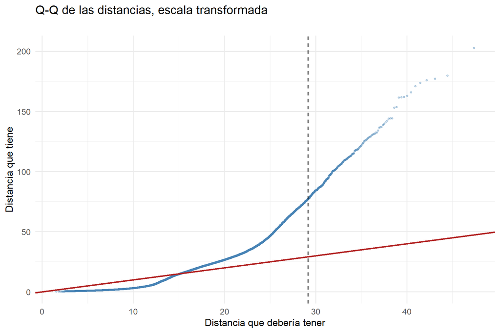

```r
qq_d2(d2_log, p, "Q-Q de las distancias, escala transformada")
```

```r
tabla_qq(d2_log, p)
```

| percentil | observada | teorica |
| --- | --- | --- |
| 50 % | 9.56 | 13.34 |
| 75 % | 20.06 | 17.12 |
| 90 % | 29.41 | 21.06 |
| 95 % | 38.86 | 23.68 |
| 99 % | 77.05 | 29.14 |
| 99,9 % | 129.44 | 36.12 |

```r
tabla_cortes(d2_log, p)
```

| corte | valor_de_la_distancia | esperados_por_encima | observados | observados_pct |
| --- | --- | --- | --- | --- |
| 95 % | 23.68 | 5 % | 5278 | 17.59 % |
| 99 % | 29.14 | 1 % | 3076 | 10.25 % |
| 99,9 % | 36.12 | 0,1 % | 1767 | 5.89 % |

```r
mardia(Mt[idx_mardia, ])
```

| prueba | estadistico | p_valor |
| --- | --- | --- |
| Asimetría | 22832.72 | < 0.001 |
| Curtosis | 212.84 | < 0.001 |

Comparación directa de las dos escalas:

```r
c99  <- qchisq(0.99,  df = p)
c999 <- qchisq(0.999, df = p)
data.frame(
  escala = c("original", "transformada"),
  sobre_corte_99  = c(sum(d2_crudo > c99),  sum(d2_log > c99)),
  sobre_corte_999 = c(sum(d2_crudo > c999), sum(d2_log > c999)),
  esperado_99  = round(0.01  * nrow(M)),
  esperado_999 = round(0.001 * nrow(M)))
```

| escala | sobre_corte_99 | sobre_corte_999 | esperado_99 | esperado_999 |
| --- | --- | --- | --- | --- |
| original | 2318 | 1920 | 300 | 30 |
| transformada | 3076 | 1767 | 300 | 30 |

La transformación acercó bastante la base a una campana multivariante pero **no corrige el centro**: el Q-Q se despega todavía antes del corte 99 % y las asimetrías quedaron negativas. Ese giro de signo es la pista: hay **muchos ceros en los pagos**, y como `log1p(0) = 0`, esos ceros forman un **piso** que el logaritmo no puede separar, amontonando masa en el mínimo y generando la nueva cola izquierda. Por eso suben los clientes sobre el 99 % (el cuerpo se ensancha) aunque bajen los del 99,9 % (la cola larga sí se comprimió). Lo que sigue sin corregirse es, entonces, estructural: una mezcla de “paga / no paga” que ninguna transformación monótona de una sola variable va a volver gaussiana.

# 5 Los clientes más lejanos

Se deja la escala elegida como parámetro, para cambiarla en un solo lugar: `"transformada"` o `"cruda"`. Los clientes que pasan el corte del 99 % son la lista de casos a revisar uno por uno: no se borran por estar en la lista, se revisan.

```r
escala_final <- "transformada"   # cambiar a "cruda" si el Q-Q transformado no mejora al original

Mf <- if (escala_final == "transformada") Mt else M
d2 <- mahal2(Mf)
raros <- d2 > qchisq(0.99, df = p)

c(escala = escala_final, clientes_raros = sum(raros),
  porcentaje = round(100 * mean(raros), 2))
```

```
##         escala clientes_raros     porcentaje
## "transformada"         "3076"        "10.25"
```

Los cinco más lejanos, con sus valores en la escala original y la relación entre su factura de septiembre y su límite de crédito:

```r
top5 <- order(d2, decreasing = TRUE)[1:5]
data.frame(ID = credit$ID[top5],
           credit[top5, continuas],
           factura1_sobre_limite = round(credit$BILL_AMT1[top5] / credit$LIMIT_BAL[top5], 2),
           mahalanobis = round(d2[top5], 1),
           row.names = NULL)
```

| ID | LIMIT_BAL | AGE | BILL_AMT1 | BILL_AMT2 | BILL_AMT3 | BILL_AMT4 | BILL_AMT5 | BILL_AMT6 | PAY_AMT1 | PAY_AMT2 | PAY_AMT3 | PAY_AMT4 | PAY_AMT5 | PAY_AMT6 | factura1_sobre_limite | mahalanobis |
| --- | --- | --- | --- | --- | --- | --- | --- | --- | --- | --- | --- | --- | --- | --- | --- | --- |
| 28720 | 360000 | 39 | 366965 | -17710 | -17706 | 301085 | 307035 | 63451 | 12709 | 1393 | 319494 | 13079 | 2438 | 2599 | 1.02 | 202.8 |
| 8356 | 260000 | 36 | 88273 | 91908 | 90857 | -81334 | 142645 | 149655 | 6000 | 5020 | 81569 | 331788 | 10002 | 5003 | 0.34 | 179.9 |
| 1651 | 500000 | 45 | 36954 | -24704 | 22999 | 18339 | -3876 | 15586 | 0 | 83000 | 0 | 0 | 20000 | 18000 | 0.07 | 177.2 |
| 9410 | 440000 | 28 | 8325 | -4341 | -15641 | 7059 | -4220 | -16370 | 0 | 752 | 34000 | 284 | 3650 | 52719 | 0.02 | 175.9 |
| 23327 | 260000 | 36 | 122825 | 88273 | 91908 | 90857 | -81334 | 142645 | 5000 | 6000 | 5020 | 81569 | 331788 | 10002 | 0.47 | 173.9 |

- **ID 28720** factura de septiembre ≈ 1,02× el límite: candidato a **tope de escala o error de coherencia** (una factura no debería superar el cupo); hay que verificar con los pagos y si es un valor redondeado al máximo.
- **Facturas negativas** (BILL_AMT2/3 en 28720, 1651, 9410; BILL_AMT4 en
  8356. son **saldos a favor**, no errores en sí; un atípico real, no un dato a corregir, salvo que choquen con los pagos.
- **IDs 8356 y 23327** comparten valores casi idénticos cruzados entre variables: revisar si es **duplicación/registro espejado** (posible error) o coincidencia.
- **IDs 1651 y 9410** límites altos y montos moderados: perfiles plausibles, probables **atípicos reales** (clientes verdaderos poco comunes), no errores.

# 6 Conclusión

en escala original el Q-Q se curva desde el centro las distancias del 50 % y 75 % caen muy por debajo de la teórica y la cola explota hasta ~8.000, señal de que los datos crudos no son una campana multivariante y no es confiable como referencia. Tras transformar (log/slog/log1p en montos) el Q-Q mejora mucho: la cola se encoge a ~200 y la base se acerca a la recta, aunque sigue despegándose antes del corte 99 % por el piso de ceros de los pagos. Se **decidió seguir en la escala transformada**, que es la que más se aproxima a la normalidad multivariante y hace interpretables las distancias.